# Logistic Regression

ChatGPT 4o

2025-01-21

## 1 起源

逻辑回归（Logistic Regression）是一种由生物统计学家戴维·考克斯（David Cox）在20世纪50年代开发的统计方法，最初用于分析二分类数据与多个预测变量之间的关系。逻辑回归是一种广泛应用于生物医学、社会科学和经济学等领域的回归模型，用于解决分类问题。随着机器学习的兴起，逻辑回归已成为二分类问题中最常用的工具之一。

## 2 原理

逻辑回归是一种用于二分类问题的回归分析方法。其核心思想是通过对因变量进行逻辑函数（Logistic Function）转换，将因变量的取值范围压缩在0和1之间，以此来预测某个事件发生的概率。

逻辑回归模型的数学形式为：

$$P(Y=1|X) = \frac{1}{1 + e^{-(\beta_0 + \beta_1 X_1 + \beta_2 X_2 +
\cdots + \beta_p X_p)}}$$

其中，$P(Y=1|X)$ 表示给定自变量$X$时事件$Y=1$发生的概率，$\beta_0$ 为截距，$\beta_1, \beta_2, \cdots, \beta_p$ 为自变量的回归系数。

通过最大似然估计（Maximum Likelihood Estimation），可以求得模型参数，使得观测数据的可能性最大化。逻辑回归模型可以输出一个介于0和1之间的概率值，通过设定阈值（通常为0.5），将概率值转化为类别标签（0或1）。

## 3 适用范围

逻辑回归适用于以下情况：

- **二分类问题**：因变量为二分类（例如成功与失败、患病与健康等）。
- **自变量**：自变量可以是连续型、分类型或二者的组合。
- **数据无多重共线性**：自变量之间不应存在多重共线性，以避免模型参数的不稳定性。

逻辑回归还可以扩展到多分类问题（多项逻辑回归）和顺序分类问题（有序逻辑回归）。

## 4 应用情境

逻辑回归在许多实际应用中都有广泛的应用，例如：

- **医学研究**：用于预测患者是否患有某种疾病，基于年龄、体重、血压等变量。
- **市场营销**：用于预测客户是否会购买某个产品，基于客户的行为数据。
- **社会科学**：用于分析某个社会行为（如投票、捐款）是否发生的概率。
- **信用评分**：用于预测借款人是否会违约，基于其信用记录和收入等信息。

## 5 优缺点

### 优点

- **解释性强**：逻辑回归模型的回归系数可以解释自变量对因变量的影响方向和大小。
- **计算简单**：计算过程相对简单，适合处理大量样本和多种类型的自变量。
- **概率输出**：可以输出事件发生的概率，适合需要概率解释的场景。

### 缺点

- **只能处理线性关系**：逻辑回归只能捕捉自变量与因变量之间的线性关系，无法处理复杂的非线性关系。
- **对异常值敏感**：模型对异常值较为敏感，容易受到极端值的影响。
- **需要独立性假设**：假设自变量之间相互独立，多重共线性会影响模型的稳定性和准确性。

## 6 在R中的实现及结果解释

在R中，逻辑回归可以通过`glm()`函数实现。以下是一个实现示例：

```r
# 示例数据：预测客户是否购买某产品（0 = 未购买, 1 = 购买）
# 创建数据框
set.seed(123)
data <- data.frame(
  Age = rnorm(100, mean = 35, sd = 10),
  Income = rnorm(100, mean = 50000, sd = 15000),
  Purchased = sample(0:1, 100, replace = TRUE)
)
data
```

```
##          Age   Income Purchased
## 1   29.39524 39343.90         0
## 2   32.69823 53853.26         0
## 3   50.58708 46299.62         0
## 4   35.70508 44786.86         0
## 5   36.29288 35725.72         0
## 6   52.15065 49324.58         0
## 7   39.60916 38226.43         1
## 8   22.34939 24980.87         0
## 9   28.13147 44296.60         1
## 10  30.54338 63784.95         0
## 11  47.24082 41369.80         1
## 12  38.59814 59119.46         1
## 13  39.00771 25731.76         1
## 14  36.10683 49166.57         1
```

[output cut: 86 more lines]

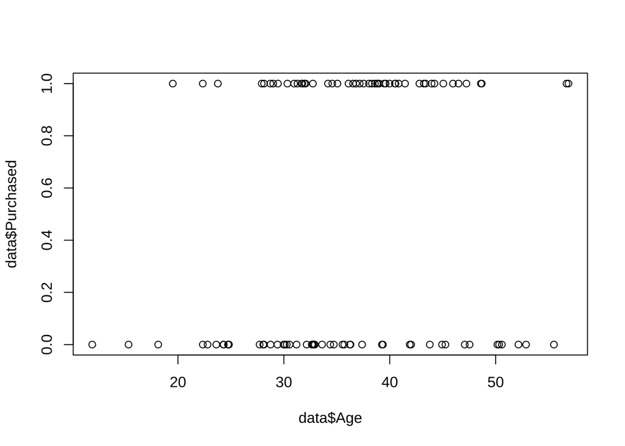

```r
plot(data$Age, data$Purchased)
```

```r
# 进行逻辑回归
logit_model <- glm(Purchased ~ Age + Income, data = data, family = binomial())

logit_model
```

```
##
## Call:  glm(formula = Purchased ~ Age + Income, family = binomial(),
##     data = data)
##
## Coefficients:
## (Intercept)          Age       Income
##  -1.936e+00    4.167e-02    9.092e-06
##
## Degrees of Freedom: 99 Total (i.e. Null);  97 Residual
## Null Deviance:       138.6
## Residual Deviance: 134.9     AIC: 140.9
```

```r
summary(logit_model)
```

```
##
## Call:
## glm(formula = Purchased ~ Age + Income, family = binomial(),
##     data = data)
##
## Coefficients:
##               Estimate Std. Error z value Pr(>|z|)
## (Intercept) -1.936e+00  1.133e+00  -1.710   0.0873 .
## Age          4.167e-02  2.320e-02   1.796   0.0724 .
## Income       9.092e-06  1.410e-05   0.645   0.5190
## ---
## Signif. codes:  0 '***' 0.001 '**' 0.01 '*' 0.05 '.' 0.1 ' ' 1
##
## (Dispersion parameter for binomial family taken to be 1)
##
##     Null deviance: 138.63  on 99  degrees of freedom
## Residual deviance: 134.94  on 97  degrees of freedom
## AIC: 140.94
##
## Number of Fisher Scoring iterations: 4
```

```r
str(logit_model)
```

[output not shown]

[output cut: 48 more lines]

[output not shown]

```r
logit_model$coefficients
```

```
##   (Intercept)           Age        Income
## -1.936490e+00  4.166711e-02  9.092409e-06
```

```r
logit_model$fitted.values
```

```
##         1         2         3         4         5         6         7         8
## 0.4124262 0.4789140 0.6438932 0.4896160 0.4751610 0.6648439 0.5153650 0.3147253
##         9        10        11        12        13        14        15        16
## 0.4105795 0.4790430 0.6006200 0.5521400 0.4807126 0.5037548 0.4540590 0.6818111
##        17        18        19        20        21        22        23        24
## 0.5494210 0.2828564 0.5381323 0.4109120 0.3887887 0.4394075 0.3733358 0.4104377
##        25        26        27        28        29        30        31        32
## 0.4918808 0.3067762 0.5884749 0.5127517 0.3477524 0.6199137 0.5869064 0.4787903
##        33        34        35        36        37        38        39        40
## 0.5878479 0.5707102 0.5096922 0.6029362 0.5020174 0.5128973 0.5273149 0.4063731
##        41        42        43        44        45        46        47        48
## 0.4458948 0.4635860 0.3175197 0.6623179 0.5649742 0.3626465 0.4035357 0.4690047
##        49        50        51        52        53        54        55        56
## 0.6428817 0.4418169 0.5472254 0.5173608 0.5009810 0.6008978 0.4665787 0.6387877
##        57        58        59        60        61        62        63        64
## 0.3561629 0.5422180 0.5402455 0.5038419 0.5691145 0.4071119 0.4172126 0.4985253
##        65        66        67        68        69        70        71        72
## 0.3712264 0.5358446 0.5621899 0.4831522 0.6061731 0.7070318 0.4359798 0.2735312
##        73        74        75        76        77        78        79        80
## 0.5964981 0.4928172 0.3985999 0.5632411 0.4657975 0.3799375 0.5278608 0.4640851
##        81        82        83        84        85        86        87        88
## 0.4585598 0.5767132 0.4438252 0.5316895 0.4631627 0.5219436 0.6421890 0.5422400
##        89        90        91        92        93        94        95        96
## 0.4858826 0.5955741 0.6034093 0.5400882 0.5221983 0.3995678 0.5901652 0.4996901
##        97        98        99       100
## 0.7250808 0.6093111 0.4489077 0.3514016
```

### 结果解释

运行上述代码后，将输出逻辑回归的结果，主要包括以下内容：

- **回归系数（Estimate）**：表示各自变量对因变量的影响大小。正系数表示自变量增加时，事件发生的概率增加；负系数表示相反。
- **标准误差（Std. Error）**：表示系数估计值的不确定性。
- **z值和p值**：用于检验自变量对因变量的显著性。如果p值小于显著性水平（如0.05），则认为该自变量对因变量具有显著影响。
- **(Intercept) = -1.936**：截距的估计值为-1.936。
- **Age = 0.042**：年龄对购买概率的影响为正，p值为0.072，表示不显著。
- **Income = 0.000009**：收入对购买概率的影响为正，p值为0.519，表示不显著。

```r
# 定义函数
get_or_table <- function(model) {
  # 提取系数、置信区间
  coefficients <- coef(model)
  conf_int <- confint(model)

  # 转换为 OR 值及其置信区间
  OR <- exp(coefficients)
  OR_conf_int <- exp(conf_int)

  # 创建结果表
  results <- data.frame(
    Term = names(coefficients),
    Coefficient = coefficients,
    OR = OR,
    Lower_CI = OR_conf_int[, 1],
    Upper_CI = OR_conf_int[, 2]
  )

  return(results)
}

# 调用函数
or_table <- get_or_table(logit_model)
print(or_table)
```

```
##                    Term   Coefficient        OR   Lower_CI Upper_CI
## (Intercept) (Intercept) -1.936490e+00 0.1442092 0.01434777 1.262895
## Age                 Age  4.166711e-02 1.0425474 0.99735105 1.093146
## Income           Income  9.092409e-06 1.0000091 0.99998136 1.000037
```

```r
library(broom)

# 使用 tidy() 格式化回归结果
tidy_model <- tidy(logit_model, conf.int = TRUE, exp = TRUE)

print(tidy_model)
```

```
## # A tibble: 3 × 7
##   term        estimate std.error statistic p.value conf.low conf.high
##   <chr>          <dbl>     <dbl>     <dbl>   <dbl>    <dbl>     <dbl>
## 1 (Intercept)    0.144 1.13         -1.71   0.0873   0.0143      1.26
## 2 Age            1.04  0.0232        1.80   0.0724   0.997       1.09
## 3 Income         1.00  0.0000141     0.645  0.519    1.00        1.00
```

```r
# ROC曲线，评估模型的分类性能
# 安装并加载 pROC 包
#install.packages("pROC")
library(pROC)
# 示例 Logistic 回归模型

# 预测概率
predicted_probs <- predict(logit_model, type = "response")

# 绘制 ROC 曲线并计算 AUC
roc_obj <- roc(data$Purchased, predicted_probs)
```

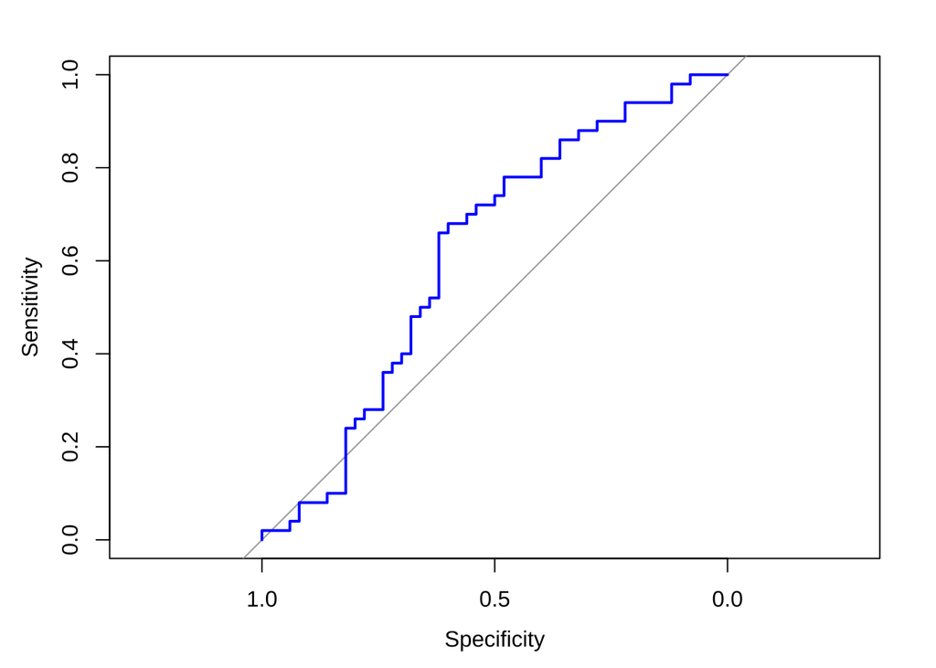

```r
plot(roc_obj, col = "blue")
```

```r
# AUC 值衡量模型分类能力（0.5 表示随机分类，1 表示完美分类）
auc(roc_obj)
```

```
## Area under the curve: 0.6148
```

```r
# Hosmer-Lemeshow 检验
# 检验模型的拟合优度（Goodness-of-Fit）。
# 判断模型预测值与实际值是否有显著差异。
# 安装并加载 ResourceSelection 包
# install.packages("ResourceSelection")
library(ResourceSelection)
```

```
## ResourceSelection 0.3-6   2023-06-27
```

```r
# Hosmer-Lemeshow 检验
hoslem_test <- hoslem.test(data$Purchased, predicted_probs, g = 10)
# p 值 > 0.05：模型拟合优度良好
print(hoslem_test)
```

```
##
##  Hosmer and Lemeshow goodness of fit (GOF) test
##
## data:  data$Purchased, predicted_probs
## X-squared = 6.7091, df = 8, p-value = 0.5683
```

```r
# 伪 R² 指标
# 衡量模型的解释力，类似于线性回归中的 R²。
# Logistic 回归中常用的伪 R² 指标包括 McFadden's R²、Nagelkerke R² 等。
# 安装并加载 pscl 包
# install.packages("pscl")
library(pscl)
# 计算 McFadden's R²
pseudo_r2 <- pR2(logit_model)
```

```
## fitting null model for pseudo-r2
```

```r
# McFadden's R²：0.2 - 0.4 通常表示模型拟合良好
# llh -- Log-likelihood of the model
print(pseudo_r2)
```

```
##          llh      llhNull           G2     McFadden         r2ML         r2CU
## -67.47178481 -69.31471806   3.68586648   0.02658791   0.03618765   0.04825020
```

```r
# 安装并加载 rcompanion 包
# install.packages("rcompanion")
library(rcompanion)

# 计算 Nagelkerke R²
nagelkerke_result <- nagelkerke(logit_model)
# 解决了 Cox & Snell R^2最大值无法达到1的问题，更常用

print(nagelkerke_result)
```

```
## $Models
##
## Model: "glm, Purchased ~ Age + Income, binomial(), data"
## Null:  "glm, Purchased ~ 1, binomial(), data"
##
## $Pseudo.R.squared.for.model.vs.null
##                              Pseudo.R.squared
## McFadden                            0.0265879
## Cox and Snell (ML)                  0.0361877
## Nagelkerke (Cragg and Uhler)        0.0482502
##
## $Likelihood.ratio.test
##  Df.diff LogLik.diff  Chisq p.value
##       -2     -1.8429 3.6859 0.15835
##
## $Number.of.observations
##
## Model: 100
## Null:  100
##
## $Messages
## [1] "Note: For models fit with REML, these statistics are based on refitting with ML"
##
## $Warnings
## [1] "None"
```

```r
# 手工计算
# 提取对数似然值
llh <- logLik(logit_model)  # 当前模型
llh
```

```
## 'log Lik.' -67.47178 (df=3)
```

```r
llhNull <- logLik(update(logit_model, . ~ 1))  # 空模型
llhNull
```

```
## 'log Lik.' -69.31472 (df=1)
```

```r
# 样本量
n <- nobs(logit_model)
n
```

```
## [1] 100
```

```r
# 计算 Cox & Snell R²
cox_snell_r2 <- 1 - exp((2 * (llhNull - llh)) / n)
cox_snell_r2
```

```
## 'log Lik.' 0.03618765 (df=1)
```

```r
# 计算 Nagelkerke R²
nagelkerke_r2 <- cox_snell_r2 / (1 - exp(2 * as.numeric(llhNull) / n))
nagelkerke_r2
```

```
## 'log Lik.' 0.0482502 (df=1)
```

计算公式：
$$R^2_{\text{Cox&Snell}} = 1 -
\exp\left(2\frac{\text{llh}_{\text{Null}} -
\text{llh}_{\text{Model}}}{n}\right)$$
$$R^2_{\text{Nagelkerke}} = \frac{R^2_{\text{Cox\&Snell}}}{1 -
\exp\left(-\frac{-2 \cdot \text{llh}_{\text{Null}}}{n}\right)}$$

### 结果的可视化

可以使用R中的`ggplot2`包对逻辑回归的结果进行可视化，以展示自变量与因变量之间的关系。

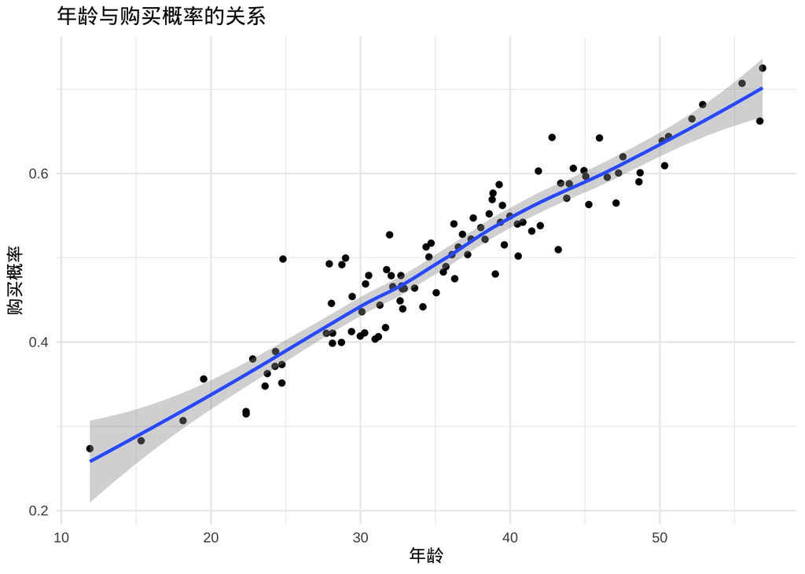

```r
# 加载ggplot2包
library(ggplot2)

# 绘制年龄与购买概率的关系
data$Predicted_Prob <- predict(logit_model, type = "response")

ggplot(data, aes(x = Age, y = Predicted_Prob)) +
  geom_point() +
  geom_smooth(method = "loess") +
  labs(title = "年龄与购买概率的关系", x = "年龄", y = "购买概率") +
  theme_minimal()
```

上述代码将绘制年龄与购买概率之间的关系，通过平滑曲线可以更直观地看到年龄对购买概率的影响。

## 7 小结

- 逻辑回归是一种用于二分类问题的回归分析方法，能够输出事件发生的概率。
- 适用于因变量为二分类，自变量可以是连续或分类变量的情况。
- 具有解释性强、计算简单等优点，但只能处理线性关系，且对异常值敏感。
- 可以通过R中的`glm()`函数实现逻辑回归，并结合可视化更直观地展示结果。
- 在医学、市场营销、社会科学等领域有广泛的应用价值。